# Assignment 1 - House Prices Kaggle Competition with scikit-learn

The authors of this work are:

- **Ion Bueno Ulacia: NIA 100364530**
- **Daniel Martín Cruz: NIA 100384121**

The goal of this assignment is prediction the house prices using different attributes. It corresponds with a regression problem, where different machine learning techniques can be applied.

The first step is loading some packages which are going to be used during the whole notebook.

```python
import pandas as pd
import numpy as np
from time import time
```

The original data is loaded into a DataFrame and splitted into the used data for evaluating the models ($X$ and $y$) and the one used in the competition ($X_{comp}$ and $y_{comp}$).

```python
file = pd.read_csv("kaggleCompetition.csv")

data = file.values
X = data[0:1460,:-1]
y = data[0:1460,-1]
X_comp = data[1460:,:-1]
y_comp = data[1460:,-1]
```

In order to have reproducible results, the seed is fixed with the NIA of Daniel Martín (100384121) in each process where is executed a random function. It has been tried fixing the seed at the beginning of the notebook, but the results were not equal, so the best option is doing it just before each execution.

**Note**: the results could differ between different operating systems. The last execution for the deliver has been performed on Kubuntu 20.04.

```python
NIA = 100384121
```

Now the data intended for creating and evaluating the model is splitted into training and test sets using the function `train_test_split` from *scikit_learn*. It is used **one third** of the available data for testing.

```python
from sklearn.model_selection import train_test_split

np.random.seed(NIA)
X_train, X_test, y_train, y_test = train_test_split(X, y, test_size=1/3)

print(f'X_train shape: {X_train.shape}\nX_test shape: {X_test.shape}\ny_train shape: {y_train.shape}\ny_test shape: {y_test.shape}\n')
```

```
X_train shape: (973, 79)
X_test shape: (487, 79)
y_train shape: (973,)
y_test shape: (487,)
```

## 3.1. Model selection

In order to validate each of the models, 3-fold crossvalidation is employed. The mentioned NIA is used as random state in order to have reproducible results. Mention that the average score (the RMSE error in this case) for the 3-fold crossvalidation is stored as well as the spent time in two dictionaries. Only the training data should be used in this part, in order to avoid obtaining too optimistic results when models are going to be evaluated with the test set.

```python
from sklearn.model_selection import cross_val_score, KFold

cv = KFold(n_splits=3, shuffle=True, random_state=NIA)

error_dic = {} # used to store the mean error for each model validation
time_dic = {}  # used to store the spent time of each model
```

Next function prints the mean **RMSE** and spent **time** in seconds for selected models.

```python
def show_stats(keys = 'all'):
    '''Print mean RMSE and spent time in seconds

    args:
        key (str/list): keys to access to both dictionaries (error and test)

    '''
    print('-'*61)
    print(f"| {'MODEL':<27} | {'RMSE':<12} | {'TIME(SEC)':<12} |")
    print('-'*61)
    if keys == 'all':
        keys = list(error_dic.keys())
    elif isinstance(keys, str):
        keys = [keys]
    for key in keys:
        print(f"| {key:<27} | {round(error_dic[key], 5):<12} | {round(time_dic[key], 5):<12} |")
        print('-'*61)
```

### 3.1.1. Model validation with default hyper-parameters

In this section different models are validated employing the default hyper-parameters from *scikit-learn*. It is used:

- Decision tree regressor
- KNeighbors regressor
- Random forests
- Extra trees
- Histogram Gradient Boosting

#### Decision Tree Regressor

The first model corresponds with a simple Decision Tree Regressor.

```python
from sklearn.tree import DecisionTreeRegressor

# Set seed
np.random.seed(NIA)
# Init time
t_in = time()
# Training
scores = -cross_val_score(DecisionTreeRegressor(random_state=NIA),
                         X_train, y_train,
                         scoring='neg_root_mean_squared_error',
                         cv = cv)

model_name = 'DecisionTree'

# Save stats
time_dic[model_name] = time() - t_in
error_dic[model_name] = np.mean(scores)
# Show stats
show_stats(model_name)
```

```
-------------------------------------------------------------
| MODEL                       | RMSE         | TIME(SEC)    |
-------------------------------------------------------------
| DecisionTree                | 0.22584      | 0.04092      |
-------------------------------------------------------------
```

As it is shown in the results, the model is very fast.

#### KNeighbors Regressor

Second model is a KNN. However, it is very advisable to scale the samples with this method due to the negative effect they can cause in the distance calculations. A pipeline and the `StandardScaler` of *scikit-learn* are used. This scaler standardizes features by removing the mean and scaling to unit variance.

```python
from sklearn.neighbors import KNeighborsRegressor
from sklearn.pipeline import make_pipeline
from sklearn.preprocessing import StandardScaler

# Pipeline = scaler + model
pipe = make_pipeline(StandardScaler(), KNeighborsRegressor())

# Set seed
np.random.seed(NIA)
# Init time
t_in = time()
# Training
scores = -cross_val_score(pipe,
                         X_train, y_train,
                         scoring='neg_root_mean_squared_error',
                         cv = cv)

model_name = 'KNN'

# Save stats
time_dic[model_name] = time() - t_in
error_dic[model_name] = np.mean(scores)
# Show stats
show_stats(model_name)
```

```
-------------------------------------------------------------
| MODEL                       | RMSE         | TIME(SEC)    |
-------------------------------------------------------------
| KNN                         | 0.19061      | 0.04688      |
-------------------------------------------------------------
```

The results can be compared using the defined function `show_stats`. It only requires inputing the desired models in a list format.

```python
show_stats(['DecisionTree', 'KNN'])
```

```
-------------------------------------------------------------
| MODEL                       | RMSE         | TIME(SEC)    |
-------------------------------------------------------------
| DecisionTree                | 0.22584      | 0.04092      |
-------------------------------------------------------------
| KNN                         | 0.19061      | 0.04688      |
-------------------------------------------------------------
```

As it can be seen, the KNN model obtains a better result but it is slower than the decision tree.

#### Random Forest

Next model is a Random Forest, which is more complex than previous ones.

```python
from sklearn.ensemble import RandomForestRegressor

# Set seed
np.random.seed(NIA)
# Init time
t_in = time()
# Training
scores = -cross_val_score(RandomForestRegressor(random_state=NIA),
                         X_train, y_train,
                         scoring='neg_root_mean_squared_error',
                         cv = cv)

model_name = 'RandomForest'

# Save stats
time_dic[model_name] = time() - t_in
error_dic[model_name] = np.mean(scores)
# Show stats
show_stats(model_name)
```

```
-------------------------------------------------------------
| MODEL                       | RMSE         | TIME(SEC)    |
-------------------------------------------------------------
| RandomForest                | 0.15025      | 2.41874      |
-------------------------------------------------------------
```

As it was expected, it obtains a better result but requires a considerable increase in time.

#### Extra Trees

Now it is employed extra trees.

```python
from sklearn.ensemble import ExtraTreesRegressor

# Set seed
np.random.seed(NIA)
# Init time
t_in = time()
# Training time
scores = -cross_val_score(ExtraTreesRegressor(random_state=NIA),
                         X_train, y_train,
                         scoring='neg_root_mean_squared_error',
                         cv = cv)

model_name = 'ExtraTrees'

# Save stats
time_dic[model_name] = time() - t_in
error_dic[model_name] = np.mean(scores)
# Show stats
show_stats(model_name)
```

```
-------------------------------------------------------------
| MODEL                       | RMSE         | TIME(SEC)    |
-------------------------------------------------------------
| ExtraTrees                  | 0.15313      | 2.36805      |
-------------------------------------------------------------
```

It obtains a result similar to random forest, but spending less time.

#### Histogram Gradient Boosting

The last model is the histogram gradient boosting.

```python
from sklearn.ensemble import HistGradientBoostingRegressor

# Set seed
np.random.seed(NIA)
# Init time
t_in = time()
# Training
scores = -cross_val_score(HistGradientBoostingRegressor(random_state=NIA),
                         X_train, y_train,
                         scoring='neg_root_mean_squared_error',
                         cv = cv)

model_name = 'HistGradientBoosting'

# Save stats
time_dic[model_name] = time() - t_in
error_dic[model_name] = np.mean(scores)
# Show stats
show_stats(model_name)
```

```
-------------------------------------------------------------
| MODEL                       | RMSE         | TIME(SEC)    |
-------------------------------------------------------------
| HistGradientBoosting        | 0.1433       | 3.98889      |
-------------------------------------------------------------
```

Now all models can be compared.

```python
show_stats()
```

```
-------------------------------------------------------------
| MODEL                       | RMSE         | TIME(SEC)    |
-------------------------------------------------------------
| DecisionTree                | 0.22584      | 0.04092      |
-------------------------------------------------------------
| KNN                         | 0.19061      | 0.04688      |
-------------------------------------------------------------
| RandomForest                | 0.15025      | 2.41874      |
-------------------------------------------------------------
| ExtraTrees                  | 0.15313      | 2.36805      |
-------------------------------------------------------------
| HistGradientBoosting        | 0.1433       | 3.98889      |
-------------------------------------------------------------
```

In order to improve the results, it is necessary to perform hyper-parameter tuning, where it is searched the best combination of parameters for a model. The selected hyper-parameters per model are going to be stored in one dictionary and printed with next function.

```python
params_dic = {} # used to store the selected hyper-parameters

def show_best_params(key):
    '''Print selected hyper-parameters of a model

    args:
        key (str): key to access to the model

    '''
    print('-'*61)
    print(f"| {f'Params {key}':<34} | {'Value':<20} |")
    print('-'*61)

    for param, value in params_dic[key].items():
        if param == 'scaler':
            continue
        if isinstance(value, float):
            value = round(value, 5)
        print(f"| {param:<34} | {value:<20} |")
        print('-'*61)
```

### 3.1.2. Hyper-parameter tuning of KNN using grid-search

In this section is explored the KNN model. It is only evaluated its main parameter, the **number of neighbors**, with a grid-search. In this configuration a model is trained per each combination of parameters and the best one respect the scoring (in this case the RMSE) is selected.

In order to find the best number of neighbors, diferent ranges have been explored until it has been found the error was not decreasing.

```python
from sklearn.model_selection import GridSearchCV
from sklearn.pipeline import Pipeline

# Pipeline = scaler + model
pipe = Pipeline([('scaler', StandardScaler()), ('knn', KNeighborsRegressor())])

# Search space
param_grid = {'scaler': [StandardScaler()],           # scaler
              'knn__n_neighbors': list(range(1,21,2)) # Number of neighbors
             }

# Set seed
np.random.seed(NIA)
# Init time
t_in = time()

# Grid search
clf = GridSearchCV(pipe,
                   param_grid,
                   scoring='neg_root_mean_squared_error',
                   cv=cv,
                   n_jobs=-1)
# Training
clf.fit(X=X_train, y=y_train)

model_name = 'KNN tuned'

# Save stats
time_dic[model_name] = time() - t_in
error_dic[model_name] = -clf.best_score_
# Show stats
show_stats(['KNN', model_name])
# Save params
params_dic[model_name] = clf.best_params_
# Show params
show_best_params(model_name)
```

```
-------------------------------------------------------------
| MODEL                       | RMSE         | TIME(SEC)    |
-------------------------------------------------------------
| KNN                         | 0.19061      | 0.04688      |
-------------------------------------------------------------
| KNN tuned                   | 0.18422      | 2.89371      |
-------------------------------------------------------------
-------------------------------------------------------------
| Params KNN tuned                   | Value                |
-------------------------------------------------------------
| knn__n_neighbors                   | 7                    |
-------------------------------------------------------------
```

As it can be seen, the error is reduced changing the number of neighbors (the deault value is 5). However, the spent time is increased significantly.

### 3.1.3. Hyper-parameter tuning of Decision Tree using random-search

In this case random-search is used to tune the Decision Tree, which tests randomly only some of the combinations. The considered hyper-parameters are:

- **Maximum depth**: it is going to determine the complexity of the model. A higher degree of complexity allows to explain better the problem, but it can lead to overfitting.
- **Minimum number of samples required to split and internal node**: according to the paper, *An empirical study on hyperparameter tuning of decision trees* (https://arxiv.org/abs/1812.02207, recommended values are between 1 and 40.
- **Minimumn number of samples required to be at a leaf node**: according to the previous mentioned paper, the recommended values are between 1 and 20.

```python
from sklearn.model_selection import RandomizedSearchCV
from scipy.stats import randint

# Search space
param_grid = {'max_depth': randint(5, 20),          # maximum depth of the tree
              'min_samples_split': randint(2, 40),  # minimum number of samples required to split an internal node
              'min_samples_leaf': randint(1, 20),   # minimum number of samples required to be at a leaf node
             }

# Set seed
np.random.seed(NIA)
# Init time
t_in = time()

# Random search
clf = RandomizedSearchCV(DecisionTreeRegressor(random_state=NIA),
                         param_grid,
                         n_iter=15,
                         scoring='neg_root_mean_squared_error',
                         cv=cv,
                         n_jobs=-1,
                         random_state=NIA)
# Training
clf.fit(X=X_train, y=y_train)

model_name = 'DecisionTree tuned'

# Save stats
time_dic[model_name] = time() - t_in
error_dic[model_name] = -clf.best_score_
# Save params
params_dic[model_name] = clf.best_params_
# Show stats
show_stats(['DecisionTree', model_name])
# Show params
show_best_params(model_name)
```

```
-------------------------------------------------------------
| MODEL                       | RMSE         | TIME(SEC)    |
-------------------------------------------------------------
| DecisionTree                | 0.22584      | 0.04092      |
-------------------------------------------------------------
| DecisionTree tuned          | 0.19554      | 0.13794      |
-------------------------------------------------------------
-------------------------------------------------------------
| Params DecisionTree tuned          | Value                |
-------------------------------------------------------------
| max_depth                          | 7                    |
-------------------------------------------------------------
| min_samples_leaf                   | 6                    |
-------------------------------------------------------------
| min_samples_split                  | 6                    |
-------------------------------------------------------------
```

Different combinations in the hyper-parameters were tested. Considering the recommended ranges in `min_samples_split` and `min_samples_leaf`, the optimal values were always in this range. The point was in the depth, where increasing the range was not providing better results and could lead to overfitting. The error is decreased, but spending more time as it was expected.

### 3.1.4. Hyper-parameter tuning of Extra Trees using scikit-optimize

In this case it is employed a bayesian search, which looks for a optimized are with the given parameters. As this models is a combination of decision trees, the same three hyper-parameters are used:

- **Maximum depth**
- **Minimum number of samples required to split and internal node**
- **Minimum number of samples required to be at a leaf node**

```python
from skopt import BayesSearchCV
from skopt.space import Integer
from sklearn import metrics

# Search space with integer uniform distributions
param_grid = {'max_depth': Integer(1,16),           # maximum depth of the tree
              'min_samples_split': Integer(2,40),   # minimum number of samples required to split an internal node
              'min_samples_leaf': Integer(1,20),    # minimum number of samples required to be at a leaf node
             }

# Set seed
np.random.seed(NIA)
# Init time
t_in = time()

# Bayesian search
clf = BayesSearchCV(ExtraTreesRegressor(random_state=NIA),
                    param_grid,
                    n_iter=15,
                    scoring='neg_root_mean_squared_error',
                    cv=cv,
                    n_jobs=-1,
                    random_state=NIA)
# Training
clf.fit(X=X_train, y=y_train)

model_name = 'ExtraTrees tuned'

# Save stats
time_dic[model_name] = time() - t_in
error_dic[model_name] = -clf.best_score_
# Save params
params_dic[model_name] = clf.best_params_
# Show stats
show_stats(['ExtraTrees', model_name])
# Show params
show_best_params(model_name)
```

```
-------------------------------------------------------------
| MODEL                       | RMSE         | TIME(SEC)    |
-------------------------------------------------------------
| ExtraTrees                  | 0.15313      | 2.36805      |
-------------------------------------------------------------
| ExtraTrees tuned            | 0.1525       | 13.55696     |
-------------------------------------------------------------
-------------------------------------------------------------
| Params ExtraTrees tuned            | Value                |
-------------------------------------------------------------
| max_depth                          | 13                   |
-------------------------------------------------------------
| min_samples_leaf                   | 4                    |
-------------------------------------------------------------
| min_samples_split                  | 13                   |
-------------------------------------------------------------
```

In this case the search was more difficult, and the ranges fluctuate a lot. The set values were the best ones which can be found, as it can be seen in the table. However, the difference in time is significantly, questioning if it is worthy.

### 3.1.5. Hyper-parameter of Histogram Gradient Boosting using optuna

For the last model it is employed optuna. The explored hyperparameters are:

- **Learning rate**: also known as *shrinkage*. This is used as a multiplicative factor for the leaves values.
- **Maximum number of iterations**: the maximum number of iterations of the boosting process (maximum number of trees).
- **Maximum number of leaves for each tree**.

In optuna it is required to call an *objective* function where it is calculated the score.

```python
import optuna
from optuna.samplers import TPESampler

def objective(trial):

    # Search space
    learning_rate = trial.suggest_float('learning_rate', 0.01, 0.9)    # learning rate
    max_iter = trial.suggest_int('max_iter', 50, 150)                  # maximum number of iterations
    max_leaf_nodes = trial.suggest_int('max_leaf_nodes', 10, 40)       # maximum number of leaves for each tree

    # Model
    clf = HistGradientBoostingRegressor(learning_rate=learning_rate,
                                        max_iter=max_iter,
                                        max_leaf_nodes=max_leaf_nodes,
                                        random_state = NIA)
    # Training
    scores = -cross_val_score(clf, X_train, y_train,
                              scoring='neg_root_mean_squared_error',
                              n_jobs=-1,
                              cv=cv)
    return scores.mean()
```

Once the objective function is declared, it is defined a number of trials (in this case 15) and it is defined if the objective should be minimized of maximized (in this case minimize the RMSE). The selected hyperparameters of the trial with the best result are selected.

```python
# Create study
study = optuna.create_study(direction="minimize", sampler=TPESampler(seed=NIA)) # sampler with fixed seed to ensure reproducibility
budget = 15 # number of trials

# Set seed
np.random.seed(NIA)
# Init time
t_in = time()

# Call optimization function
study.optimize(objective, n_trials=budget)

model_name = "HistGradientBoosting tuned"

# Save stats
time_dic[model_name] = time() - t_in
error_dic[model_name] = study.best_value
# Save params
params_dic[model_name] = study.best_params
# Show stats
show_stats(['HistGradientBoosting', model_name])
# Show params
show_best_params(model_name)
```

```
[I 2022-01-05 23:25:09,893] A new study created in memory with name: no-name-73cf7e7b-6e70-4bd7-8197-1dfc51c2ff4e
[I 2022-01-05 23:25:10,508] Trial 0 finished with value: 0.15694974802153014 and parameters: {'learning_rate': 0.400466767291078, 'max_iter': 81, 'max_leaf_nodes': 22}. Best is trial 0 with value: 0.15694974802153014.
[I 2022-01-05 23:25:11,232] Trial 1 finished with value: 0.16691483594610598 and parameters: {'learning_rate': 0.5605062141618219, 'max_iter': 83, 'max_leaf_nodes': 29}. Best is trial 0 with value: 0.15694974802153014.
[I 2022-01-05 23:25:11,964] Trial 2 finished with value: 0.17818334239751832 and parameters: {'learning_rate': 0.015495742286724363, 'max_iter': 105, 'max_leaf_nodes': 17}. Best is trial 0 with value: 0.15694974802153014.
[I 2022-01-05 23:25:12,822] Trial 3 finished with value: 0.14808938751213707 and parameters: {'learning_rate': 0.24163268022464632, 'max_iter': 108, 'max_leaf_nodes': 28}. Best is trial 3 with value: 0.14808938751213707.
[I 2022-01-05 23:25:13,355] Trial 4 finished with value: 0.1414037602993263 and parameters: {'learning_rate': 0.05166400405913564, 'max_iter': 109, 'max_leaf_nodes': 12}. Best is trial 4 with value: 0.1414037602993263.
[I 2022-01-05 23:25:13,795] Trial 5 finished with value: 0.15485463432021293 and parameters: {'learning_rate': 0.37420653117027797, 'max_iter': 119, 'max_leaf_nodes': 10}. Best is trial 4 with value: 0.1414037602993263.
[I 2022-01-05 23:25:14,594] Trial 6 finished with value: 0.15680624315514669 and parameters: {'learning_rate': 0.390362286062775, 'max_iter': 101, 'max_leaf_nodes': 31}. Best is trial 4 with value: 0.1414037602993263.
[I 2022-01-05 23:25:15,066] Trial 7 finished with value: 0.19232929331058832 and parameters: {'learning_rate': 0.7772891870445381, 'max_iter': 82, 'max_leaf_nodes': 17}. Best is trial 4 with value: 0.1414037602993263.
[I 2022-01-05 23:25:15,570] Trial 8 finished with value: 0.19453933018192052 and parameters: {'learning_rate': 0.890479392538868, 'max_iter': 91, 'max_leaf_nodes': 15}. Best is trial 4 with value: 0.1414037602993263.
[I 2022-01-05 23:25:16,139] Trial 9 finished with value: 0.18913126746357536 and parameters: {'learning_rate': 0.8039481251993389, 'max_iter': 74, 'max_leaf_nodes': 34}. Best is trial 4 with value: 0.1414037602993263.
[I 2022-01-05 23:25:17,519] Trial 10 finished with value: 0.14671271451505685 and parameters: {'learning_rate': 0.02401456437715549, 'max_iter': 148, 'max_leaf_nodes': 40}. Best is trial 4 with value: 0.1414037602993263.
[I 2022-01-05 23:25:18,773] Trial 11 finished with value: 0.1710718469643214 and parameters: {'learning_rate': 0.012387186797349868, 'max_iter': 143, 'max_leaf_nodes': 39}. Best is trial 4 with value: 0.1414037602993263.
[I 2022-01-05 23:25:19,179] Trial 12 finished with value: 0.1455054847600764 and parameters: {'learning_rate': 0.19328713959156607, 'max_iter': 53, 'max_leaf_nodes': 23}. Best is trial 4 with value: 0.1414037602993263.
[I 2022-01-05 23:25:19,609] Trial 13 finished with value: 0.14529465698035238 and parameters: {'learning_rate': 0.1886187814547335, 'max_iter': 54, 'max_leaf_nodes': 23}. Best is trial 4 with value: 0.1414037602993263.
[I 2022-01-05 23:25:19,834] Trial 14 finished with value: 0.14283915665784494 and parameters: {'learning_rate': 0.1807674254047782, 'max_iter': 50, 'max_leaf_nodes': 10}. Best is trial 4 with value: 0.1414037602993263.
```

```
-------------------------------------------------------------
| MODEL                       | RMSE         | TIME(SEC)    |
-------------------------------------------------------------
| HistGradientBoosting        | 0.1433       | 3.98889      |
-------------------------------------------------------------
| HistGradientBoosting tuned  | 0.1414       | 9.94041      |
-------------------------------------------------------------
-------------------------------------------------------------
| Params HistGradientBoosting tuned  | Value                |
-------------------------------------------------------------
| learning_rate                      | 0.05166              |
-------------------------------------------------------------
| max_iter                           | 109                  |
-------------------------------------------------------------
| max_leaf_nodes                     | 12                   |
-------------------------------------------------------------
```

As it was expected, it is obatined a better reult than the default model. Altough there is not a great difference in the error and the tuned version takes long time. As with Extra Trees, the tuning process is cuestionable in terms of performance for this model and this problem.

### 3.1.6. Plotting facilities of Optuna

In this section different plotting features of optuna are explored in order to help visualizing the optimization process.

**Note**: as it is commented in the official page of optuna (https://optuna.readthedocs.io/en/stable/reference/visualization/index.html), in the `optuna.visualization` module, the following functions use plotly to create figures, but JupyterLab cannot render them by default. The guide in https://github.com/plotly/plotly.py#jupyterlab-support-python-35 explains how to show figures in JupyterLab.

#### Optimization History Plot

It presents the score in each trial. A straight line is plotted showing the best obtained value during the whole process. It can be seen how the best value is initiated with the score of the first trial and how this one changes with the trial number 3 and finally is set up with the trial number 4.

```python
from optuna.visualization import *
import plotly.graph_objects as go

fig = plot_optimization_history(study)
fig.show()
```

#### Hyperparameters Importance Plot

Now it is presented the weight of each tuned hyperparameter in terms of the objective value, the RMSE in this case. As it can be seen, the most important one is the `learning_rate`, with a significant difference respect `max_leaf_nodes` and `max_iter`.

```python
fig = plot_param_importances(study)
fig.show()
```

#### Slice Plot

The values of each hyperparameter are plotted in a scatter plot respect the objective value. In this case as there are three tuned hyperparameters, three scatter plots are presented. As it was mentioned, `learning_rate` is the most critical one, and it can be appreciated how it has almost a positive correlation with the objective value. However, in the other two there are not any clear pattern, due to their small weight into the objective.

```python
fig = plot_slice(study)
fig.show()
```

#### Contour Plot

It corresponds with a pairs plot of the tuned hyperparameters, where the objective value is also shown. The darker areas correspond with smaller errors and lighter with larger ones. As it can be seen the trials are distributed almost homogeneously in all areas.

```python
fig = plot_contour(study)
fig.show()
```

#### Parallel Coordinate Plot

Last plot corresponds with a PCP (parallel corrdinate plot) where ther selected hyperparameters of each trial are matched between them and with the corresponding objective value. In this case there is not a clear pattern between the trials, which is a good sign, since it indicates heterogeneous combinatios of hyperparameeters are tested. Mention how the one with less error has a small `learning_rate`.

```python
fig = plot_parallel_coordinate(study)
fig.show()
```

#### Pruning Unpromising Trials

This feature automatically stops unpromising trials at the early stages of the training (automated early-stopping). For the case of plotting intermediate values it is needed a regression model capable of doing partial fits as **SDG**. This is why it is used this regressor for the tuning of parameters.

```python
from optuna.visualization import plot_intermediate_values
from sklearn.linear_model import SGDRegressor

X_train_2, X_val, y_train_2, y_val = train_test_split(X_train, y_train, test_size=1/3, random_state=NIA)

def objective_2(trial):

    # Search space
    l1_ratio = trial.suggest_float('l1_ratio=0.15', 0.1, 0.3)    # learning rate
    max_iter = trial.suggest_int('max_iter', 500, 1500)          # maximum number of leaves for each tree

    # Model
    clf = SGDRegressor(l1_ratio=l1_ratio,
                       max_iter=max_iter,
                       random_state=NIA)

    for step in range(100):
        clf.partial_fit(X_train_2, y_train_2)

        # Report intermediate objective value.
        intermediate_value = -clf.score(X_val, y_val)
        trial.report(intermediate_value, step)

        # Handle pruning based on the intermediate value.
        if trial.should_prune():
            raise optuna.exceptions.TrialPruned()

    return clf.score(X_val, y_val)
```

```python
# Create study
study_2 = optuna.create_study(direction="minimize", sampler=TPESampler(seed=NIA)) # sampler with fixed seed to ensure reproducibility
budget = 10 # number of trials

# Set seed
np.random.seed(NIA)
# Init time
t_in = time()

# Call optimization function
study_2.optimize(objective_2, n_trials=budget)
```

```
[I 2022-01-05 23:25:21,103] A new study created in memory with name: no-name-3df4476a-83cc-43a3-baa6-5195431654d6
[I 2022-01-05 23:25:21,233] Trial 0 finished with value: -2.934777062840469e+33 and parameters: {'l1_ratio=0.15': 0.1877453409642872, 'max_iter': 807}. Best is trial 0 with value: -2.934777062840469e+33.
[I 2022-01-05 23:25:21,357] Trial 1 finished with value: -2.934777062840469e+33 and parameters: {'l1_ratio=0.15': 0.18247633328153742, 'max_iter': 1119}. Best is trial 0 with value: -2.934777062840469e+33.
[I 2022-01-05 23:25:21,522] Trial 2 finished with value: -2.934777062840469e+33 and parameters: {'l1_ratio=0.15': 0.16563410750627108, 'max_iter': 1139}. Best is trial 0 with value: -2.934777062840469e+33.
[I 2022-01-05 23:25:21,660] Trial 3 finished with value: -2.934777062840469e+33 and parameters: {'l1_ratio=0.15': 0.10123499826667964, 'max_iter': 1046}. Best is trial 0 with value: -2.934777062840469e+33.
[I 2022-01-05 23:25:21,805] Trial 4 finished with value: -2.934777062840469e+33 and parameters: {'l1_ratio=0.15': 0.1512531887510896, 'max_iter': 760}. Best is trial 0 with value: -2.934777062840469e+33.
[I 2022-01-05 23:25:21,963] Trial 5 finished with value: -2.934777062840469e+33 and parameters: {'l1_ratio=0.15': 0.21513651141097123, 'max_iter': 1105}. Best is trial 0 with value: -2.934777062840469e+33.
[I 2022-01-05 23:25:22,128] Trial 6 finished with value: -2.934777062840469e+33 and parameters: {'l1_ratio=0.15': 0.1093626975413788, 'max_iter': 1086}. Best is trial 0 with value: -2.934777062840469e+33.
[I 2022-01-05 23:25:22,274] Trial 7 finished with value: -2.934777062840469e+33 and parameters: {'l1_ratio=0.15': 0.11426658352581326, 'max_iter': 909}. Best is trial 0 with value: -2.934777062840469e+33.
[I 2022-01-05 23:25:22,440] Trial 8 finished with value: -2.934777062840469e+33 and parameters: {'l1_ratio=0.15': 0.2378885482393271, 'max_iter': 501}. Best is trial 0 with value: -2.934777062840469e+33.
[I 2022-01-05 23:25:22,611] Trial 9 finished with value: -2.934777062840469e+33 and parameters: {'l1_ratio=0.15': 0.1854746710253427, 'max_iter': 1013}. Best is trial 0 with value: -2.934777062840469e+33.
```

In the following plot we can get visual information of all those intermediate score values we get when performing partial fits on our model. We can expect a decreasing trend meaning that our model is improving its performance with each new trial.

```python
fig = plot_intermediate_values(study_2)
fig.show()
```

### 3.1.7. Models comparisons

In this part all models are compared in terms of error and spent time. It is also considered a "Dummy" regressor which provides the mean of the training set as prediction.

```python
from sklearn.dummy import DummyRegressor

# Set seed
np.random.seed(NIA)
# Init time
t_in = time()

# Training
scores = -cross_val_score(DummyRegressor(),
                         X_train, y_train,
                         scoring='neg_root_mean_squared_error',
                         cv = cv)
model_name = 'Dummy'

# Save stats
time_dic[model_name] = time() - t_in
error_dic[model_name] = np.mean(scores)
# Show stats
show_stats(model_name)
```

```
-------------------------------------------------------------
| MODEL                       | RMSE         | TIME(SEC)    |
-------------------------------------------------------------
| Dummy                       | 0.39736      | 0.00499      |
-------------------------------------------------------------
```

Now the results of all models can be printed.

```python
show_stats()
```

```
-------------------------------------------------------------
| MODEL                       | RMSE         | TIME(SEC)    |
-------------------------------------------------------------
| DecisionTree                | 0.22584      | 0.04092      |
-------------------------------------------------------------
| KNN                         | 0.19061      | 0.04688      |
-------------------------------------------------------------
| RandomForest                | 0.15025      | 2.41874      |
-------------------------------------------------------------
| ExtraTrees                  | 0.15313      | 2.36805      |
-------------------------------------------------------------
| HistGradientBoosting        | 0.1433       | 3.98889      |
-------------------------------------------------------------
| KNN tuned                   | 0.18422      | 2.89371      |
-------------------------------------------------------------
| DecisionTree tuned          | 0.19554      | 0.13794      |
-------------------------------------------------------------
| ExtraTrees tuned            | 0.1525       | 13.55696     |
-------------------------------------------------------------
| HistGradientBoosting tuned  | 0.1414       | 9.94041      |
-------------------------------------------------------------
| Dummy                       | 0.39736      | 0.00499      |
-------------------------------------------------------------
```

As it was expected, all the models perform way better that the naive "Dummy" regressor from the scikit learn library.

Here it can also be seen that, in the default case, Extra Trees are actually faster than Random Forests.

Another aspect to be highlighted by watching this information is that tuning the hyper-parameters of the models in a proper way always helps us to improve their performance, althought it was confirmed that this tuning implies more human effort and it is also more time-consuming in terms of computing time.

To conclude this section, the model that will be used for the model evaluation and for the final model will be the one that proved to have a smallest error, which is the **HistGradientBoosting** regressor using the trained hyperparameters obtained by **optuna**.

```python
show_best_params('HistGradientBoosting tuned')
```

```
-------------------------------------------------------------
| Params HistGradientBoosting tuned  | Value                |
-------------------------------------------------------------
| learning_rate                      | 0.05166              |
-------------------------------------------------------------
| max_iter                           | 109                  |
-------------------------------------------------------------
| max_leaf_nodes                     | 12                   |
-------------------------------------------------------------
```

### 3.1.8. CASH problem with Extra Trees and Histogram Gradient Boosting using optuna

This section automatizes the process of selecting a model between some options and find the optimal hyperparameters employing optuna. **Extra Trees** and **Histogram Gradient Boosting** are tested, with the same hyperparameters than sections 3.1.4 and 3.1.5 respectively.

```python
def objective(trial):

    # Search space for model
    method = trial.suggest_categorical('method', ['ExtraTrees', 'HistGradientBoosting'])

    # ExtraTrees
    if(method == 'ExtraTrees'):

        # Search space hyper-parameters
        max_depth = trial.suggest_int("max_depth", 1, 16)                   # maximum depth of the tree
        min_samples_split = trial.suggest_int("min_samples_split", 2, 40)   # minimum number of samples required to split an internal node
        min_samples_leaf = trial.suggest_int("min_samples_leaf", 1, 20)     # minimum number of samples required to be at a leaf node

        # Model
        clf = ExtraTreesRegressor(max_depth=max_depth,
                                  min_samples_split=min_samples_split,
                                  min_samples_leaf=min_samples_leaf,
                                  random_state = NIA)

    # HistGradientBoosting
    else:

        # Search space hyper-parameters
        learning_rate = trial.suggest_float('learning_rate', 0.01, 0.9)      # learning rate
        max_iter = trial.suggest_int('max_iter', 50, 150)                    # maximum number of iterations
        max_leaf_nodes = trial.suggest_int('max_leaf_nodes', 10, 40)         # maximum number of leaves for each tree

        # Model
        clf = HistGradientBoostingRegressor(learning_rate=learning_rate,
                                            max_iter=max_iter,
                                            max_leaf_nodes=max_leaf_nodes,
                                            random_state = NIA)

    # Training
    scores = -cross_val_score(clf, X_train, y_train,
                              scoring='neg_root_mean_squared_error',
                              n_jobs=1, cv=cv)
    return scores.mean()
```

Same steps than before are applied for this optuna process.

```python
# Create study
study = optuna.create_study(direction="minimize", sampler=TPESampler(seed=NIA)) # sampler with fixed seed to ensure reproducibility
budget = 10 # number of trials

# Set seed
np.random.seed(NIA)
# Init time
t_in = time()

# Call optimization function
study.optimize(objective, n_trials=budget)

name = study.best_params['method']
tuned_name = f'{name} tuned'
model_name = f"{name} CASH"

# Save stats
time_dic[model_name] = time() - t_in
error_dic[model_name] = study.best_value
# Save params
params_dic[model_name] = study.best_params
# Show stats
show_stats([name, tuned_name, model_name])
# Show params
show_best_params(model_name)
```

```
[I 2022-01-05 23:25:22,904] A new study created in memory with name: no-name-63f5009a-7e2b-4606-a32c-2ccee2b29870
[I 2022-01-05 23:25:23,698] Trial 0 finished with value: 0.16279405695019034 and parameters: {'method': 'ExtraTrees', 'max_depth': 7, 'min_samples_split': 26, 'min_samples_leaf': 7}. Best is trial 0 with value: 0.16279405695019034.
[I 2022-01-05 23:25:24,694] Trial 1 finished with value: 0.15555369704076252 and parameters: {'method': 'ExtraTrees', 'max_depth': 9, 'min_samples_split': 11, 'min_samples_leaf': 6}. Best is trial 1 with value: 0.15555369704076252.
[I 2022-01-05 23:25:27,061] Trial 2 finished with value: 0.1414037602993263 and parameters: {'method': 'HistGradientBoosting', 'learning_rate': 0.05166400405913564, 'max_iter': 109, 'max_leaf_nodes': 12}. Best is trial 2 with value: 0.1414037602993263.
[I 2022-01-05 23:25:30,538] Trial 3 finished with value: 0.21094877595357878 and parameters: {'method': 'HistGradientBoosting', 'learning_rate': 0.011443255757618332, 'max_iter': 93, 'max_leaf_nodes': 25}. Best is trial 2 with value: 0.1414037602993263.
[I 2022-01-05 23:25:33,392] Trial 4 finished with value: 0.15044303031130635 and parameters: {'method': 'HistGradientBoosting', 'learning_rate': 0.2987386912838152, 'max_iter': 73, 'max_leaf_nodes': 40}. Best is trial 2 with value: 0.1414037602993263.
[I 2022-01-05 23:25:34,208] Trial 5 finished with value: 0.16862720707805534 and parameters: {'method': 'ExtraTrees', 'max_depth': 15, 'min_samples_split': 11, 'min_samples_leaf': 16}. Best is trial 2 with value: 0.1414037602993263.
[I 2022-01-05 23:25:34,909] Trial 6 finished with value: 0.1692881161279296 and parameters: {'method': 'ExtraTrees', 'max_depth': 5, 'min_samples_split': 3, 'min_samples_leaf': 6}. Best is trial 2 with value: 0.1414037602993263.
[I 2022-01-05 23:25:35,635] Trial 7 finished with value: 0.16768822126306324 and parameters: {'method': 'ExtraTrees', 'max_depth': 6, 'min_samples_split': 28, 'min_samples_leaf': 9}. Best is trial 2 with value: 0.1414037602993263.
[I 2022-01-05 23:25:36,751] Trial 8 finished with value: 0.15099973735104807 and parameters: {'method': 'ExtraTrees', 'max_depth': 11, 'min_samples_split': 4, 'min_samples_leaf': 4}. Best is trial 2 with value: 0.1414037602993263.
[I 2022-01-05 23:25:37,574] Trial 9 finished with value: 0.16017586827196298 and parameters: {'method': 'ExtraTrees', 'max_depth': 12, 'min_samples_split': 26, 'min_samples_leaf': 6}. Best is trial 2 with value: 0.1414037602993263.
```

```
-------------------------------------------------------------
| MODEL                       | RMSE         | TIME(SEC)    |
-------------------------------------------------------------
| HistGradientBoosting        | 0.1433       | 3.98889      |
-------------------------------------------------------------
| HistGradientBoosting tuned  | 0.1414       | 9.94041      |
-------------------------------------------------------------
| HistGradientBoosting CASH   | 0.1414       | 14.66975     |
-------------------------------------------------------------
-------------------------------------------------------------
| Params HistGradientBoosting CASH   | Value                |
-------------------------------------------------------------
| method                             | HistGradientBoosting |
-------------------------------------------------------------
| learning_rate                      | 0.05166              |
-------------------------------------------------------------
| max_iter                           | 109                  |
-------------------------------------------------------------
| max_leaf_nodes                     | 12                   |
-------------------------------------------------------------
```

As it was expected, the selected model is the **Histogram Gradient Boosting** (consistent with the previous comparison of model performances), with a better score than the non-tuned version. Mention that the error is the same than the one obtained in tuning process in section 3.1.5. Also, the selected hyperparameters are consistent as it is shown in next cell.

```python
show_best_params('HistGradientBoosting tuned')
show_best_params('HistGradientBoosting CASH')
```

```
-------------------------------------------------------------
| Params HistGradientBoosting tuned  | Value                |
-------------------------------------------------------------
| learning_rate                      | 0.05166              |
-------------------------------------------------------------
| max_iter                           | 109                  |
-------------------------------------------------------------
| max_leaf_nodes                     | 12                   |
-------------------------------------------------------------
-------------------------------------------------------------
| Params HistGradientBoosting CASH   | Value                |
-------------------------------------------------------------
| method                             | HistGradientBoosting |
-------------------------------------------------------------
| learning_rate                      | 0.05166              |
-------------------------------------------------------------
| max_iter                           | 109                  |
-------------------------------------------------------------
| max_leaf_nodes                     | 12                   |
-------------------------------------------------------------
```

## 3.2. Model evaluation

Once the best model is selected, Histogram Gradient Boosting, and the optimized hyperparameters, the model is evaluated with the test partition, $X_{test}$ and $y_{test}$.

```python
best_model = min(error_dic, key=error_dic.get)
show_stats(best_model)
show_best_params(best_model)
```

```
-------------------------------------------------------------
| MODEL                       | RMSE         | TIME(SEC)    |
-------------------------------------------------------------
| HistGradientBoosting tuned  | 0.1414       | 9.94041      |
-------------------------------------------------------------
-------------------------------------------------------------
| Params HistGradientBoosting tuned  | Value                |
-------------------------------------------------------------
| learning_rate                      | 0.05166              |
-------------------------------------------------------------
| max_iter                           | 109                  |
-------------------------------------------------------------
| max_leaf_nodes                     | 12                   |
-------------------------------------------------------------
```

It is employed the `mean_squared_error` metric from *scikit-learn* with `squared=False` in order to obtain the RMSE instead of the MSE.

```python
from sklearn.metrics import mean_squared_error

# Set seed
np.random.seed(NIA)

# Model
selected_model = HistGradientBoostingRegressor(**params_dic[best_model], random_state=NIA)

# Training
selected_model.fit(X_train, y_train)

# Prediction
y_pred = selected_model.predict(X_test)

# Error
rmse = mean_squared_error(y_test, y_pred, squared=False)

print(f'The obtained RMSE from {best_model} is {round(rmse, 5)}.')
```

```
The obtained RMSE from HistGradientBoosting tuned is 0.13811.
```

The expected RMSE to be obtained with the model developed in this project is **0.13811**.

## 3.3. Final Model

The last step is training the model with all the available data $X$ and making the predictions over $X_{comp}$. Calling again the `fit` method from *scikit-learn* is the same than training from scratch with the new data.

```python
# Set seed
np.random.seed(NIA)

# Final training
selected_model.fit(X, y)

# Competition prediction
y_pred = selected_model.predict(X_comp)

# Exponential transformation for competition
salePrice = np.exp(y_pred)
```

Results are converted to a DataFrame.

```python
i = np.arange(1461, 1461+len(salePrice))
submission = pd.DataFrame(data={'Id': i, 'SalePrice': salePrice})
submission
```

|  | Id | SalePrice |
| --- | --- | --- |
| 0 | 1461 | 121124.675129 |
| 1 | 1462 | 148737.060302 |
| 2 | 1463 | 176694.044289 |
| 3 | 1464 | 184297.938689 |
| 4 | 1465 | 193547.703002 |
| ... | ... | ... |
| 1454 | 2915 | 79414.880332 |
| 1455 | 2916 | 81079.564531 |
| 1456 | 2917 | 162581.097729 |
| 1457 | 2918 | 118103.192722 |
| 1458 | 2919 | 234391.244923 |

1459 rows × 2 columns

And finally is obtained the csv file for the competition.

```python
submission.to_csv('submission.csv', index=False)
```

#### Competition result

This file is uploaded to the Kaggle competition (https://www.kaggle.com/c/house-prices-advanced-regression-techniques). In next cell is shown a screenshot of the obtained score (**0.13129**) and position in the ranking (**1613**).

[figure not shown]

## 3.4. Extra

### 3.4.1. Halving hyper-parameter optimization

#### Halving Grid Search CV

This optimization method consist in evaluating all the possible combinations of hyper-parameters, but in a small subset of the training data. The candidates which obtain better results are selected and the others are discarded. Then, this reduced group of candidates are trained with more data to select the new best candidates. The process is repeated until all data is used.

```python
# explicitly require this experimental feature
from sklearn.experimental import enable_halving_search_cv
# now you can import normally from model_selection
from sklearn.model_selection import HalvingGridSearchCV

# Pipeline = scaler + model
pipe = Pipeline([('scaler', StandardScaler()), ('knn', KNeighborsRegressor())])

# Search space
param_grid = {'scaler': [StandardScaler()],           # scaler
              'knn__n_neighbors': list(range(1,21,2)) # Number of neighbors
             }

# Set seed
np.random.seed(NIA)
# Init time
t_in = time()

# Halving search
clf = HalvingGridSearchCV(pipe,
                          param_grid,
                          scoring='neg_root_mean_squared_error',
                          cv=cv,
                          n_jobs=-1,
                          random_state=NIA)
# Training
clf.fit(X=X_train, y=y_train)

name = 'KNN'
tuned_name = f'{name} tuned'
model_name = f'{name} halving'

# Save stats
time_dic[model_name] = time() - t_in
error_dic[model_name] = -clf.best_score_
# Save params
params_dic[model_name] = clf.best_params_
# Show stats
show_stats([tuned_name, model_name])
# Show params
show_best_params(tuned_name)
show_best_params(model_name)
```

```
-------------------------------------------------------------
| MODEL                       | RMSE         | TIME(SEC)    |
-------------------------------------------------------------
| KNN tuned                   | 0.18422      | 2.89371      |
-------------------------------------------------------------
| KNN halving                 | 0.18439      | 0.19548      |
-------------------------------------------------------------
-------------------------------------------------------------
| Params KNN tuned                   | Value                |
-------------------------------------------------------------
| knn__n_neighbors                   | 7                    |
-------------------------------------------------------------
-------------------------------------------------------------
| Params KNN halving                 | Value                |
-------------------------------------------------------------
| knn__n_neighbors                   | 7                    |
-------------------------------------------------------------
```

As it can be seen in the tables, with the Halving option it is obtained a similar performance in much shorter time. The hyperparameters are consistent.

#### Halving Random Search CV

This variety is the same but the candidates are sampled at random from the search space and the number of sampled candidates is determined by `n_candidates`.

```python
from sklearn.model_selection import HalvingRandomSearchCV

# Search space
param_grid = {'max_depth': randint(5, 20),          # maximum depth of the tree
              'min_samples_split': randint(2, 40),  # minimum number of samples required to split an internal node
              'min_samples_leaf': randint(1, 20),   # minimum number of samples required to be at a leaf node
             }

# Set seed
np.random.seed(NIA)
# Init time
t_in = time()

# Halving random search
clf = HalvingRandomSearchCV(DecisionTreeRegressor(random_state=NIA),
                            param_grid,
                            scoring='neg_root_mean_squared_error',
                            cv=cv,
                            n_jobs=-1,
                            random_state=NIA)
# Training
clf.fit(X=X_train, y=y_train)

name = 'DecisionTree'
tuned_name = f'{name} tuned'
model_name = f'{name} halving'

# Save stats
time_dic[model_name] = time() - t_in
error_dic[model_name] = -clf.best_score_
# Save params
params_dic[model_name] = clf.best_params_
# Show stats
show_stats([tuned_name, model_name])
# Show params
show_best_params(tuned_name)
show_best_params(model_name)
```

```
-------------------------------------------------------------
| MODEL                       | RMSE         | TIME(SEC)    |
-------------------------------------------------------------
| DecisionTree tuned          | 0.19554      | 0.13794      |
-------------------------------------------------------------
| DecisionTree halving        | 0.21797      | 0.90757      |
-------------------------------------------------------------
-------------------------------------------------------------
| Params DecisionTree tuned          | Value                |
-------------------------------------------------------------
| max_depth                          | 7                    |
-------------------------------------------------------------
| min_samples_leaf                   | 6                    |
-------------------------------------------------------------
| min_samples_split                  | 6                    |
-------------------------------------------------------------
-------------------------------------------------------------
| Params DecisionTree halving        | Value                |
-------------------------------------------------------------
| max_depth                          | 7                    |
-------------------------------------------------------------
| min_samples_leaf                   | 6                    |
-------------------------------------------------------------
| min_samples_split                  | 6                    |
-------------------------------------------------------------
```

As before, the error is incresed a bit, but now the time is even larger than the previous version. Due to tuning a Decision Tree with a random search is very fast, the halving iterations are not worthy in time. This method would be useful with more complex models where the tuning process takes long time.

The hyperparameters are the same in both searchs.

### 3.4.2. External boosting libraries

#### XGBoost

'XGBoost' comes from Extreme Gradient Boosting and refers to a ensemble ML algorithm that can be used for classification or for regression like in our example. The two main reasons to use XGBoost are execution speed and model performance. The way it achieves this is optimizing the classical boosting methods by working as Newton Raphson in function space instead of gradient descent.

```python
import xgboost

model_xgb = xgboost.XGBRegressor(n_estimators=1000, max_depth=7, eta=0.1, subsample=0.7, colsample_bytree=0.8, random_state=NIA)
t_in = time()
model_xgb.fit(X_train, y_train)
y_pred = model_xgb.predict(X_test)

score = mean_squared_error(y_test, y_pred, squared=False)  # False in order to get RMSE instead of MSE

model_name = 'XGBoost'

# Save stats
time_dic[model_name] = time() - t_in
error_dic[model_name] = score
```

#### catboost

Catboost is another algorithm for gradient boosting on decision trees developed by Yandex researches and engineers. It comes from 'Category Boosting' because this library is characterized because it can work well with multiple categories of data, such as audio, text, image including historical data.

```python
import catboost

model_cb = catboost.CatBoostRegressor(loss_function='RMSE', silent=True, random_state=NIA)
t_in = time()
model_cb.fit(X_train, y_train)
y_pred = model_cb.predict(X_test)

score = mean_squared_error(y_test, y_pred, squared=False)  # False in order to get RMSE instead of MSE

model_name = 'catboost'

# Save stats
time_dic[model_name] = time() - t_in
error_dic[model_name] = score
```

#### lightgbm

Lightgbm works in a very similar way as XGBoost does but the main difference here is in the construction of trees. LightGBM does not grow a tree level-wise — row by row — as most other implementations do. Instead it grows trees leaf-wise. It chooses the leaf it believes will yield the largest decrease in loss. Another characteristic of lightGBM is that it utilizes two novel techniques called Gradient-Based One-Side Sampling (GOSS) and Exclusive Feature Bundling (EFB) which allow the algorithm to run faster while maintaining a high level of accuracy

```python
import lightgbm

model_lgbm = lightgbm.LGBMRegressor(random_state=NIA)
t_in = time()
model_lgbm.fit(X_train, y_train)
y_pred = model_lgbm.predict(X_test)

score = mean_squared_error(y_test, y_pred, squared=False)  # False in order to get RMSE instead of MSE

model_name = 'lightgbm'

# Save stats
time_dic[model_name] = time() - t_in
error_dic[model_name] = score
```

#### Comparison of performance between external libraries

```python
show_stats(['XGBoost','catboost','lightgbm'])
```

```
-------------------------------------------------------------
| MODEL                       | RMSE         | TIME(SEC)    |
-------------------------------------------------------------
| XGBoost                     | 0.13026      | 1.41521      |
-------------------------------------------------------------
| catboost                    | 0.12663      | 3.39997      |
-------------------------------------------------------------
| lightgbm                    | 0.13813      | 0.18849      |
-------------------------------------------------------------
```

Here we can see that these three libraries offer an impresive in a considerable time even without tuning their hyper-parameters. It is also appretiable the trade-off that exists between the execution time and the score of the model, catboost is the "slowest" method of the three and it is the one with the lowest RMSE.

We wanted to see how well a model trained using one of these methods performed in the competition, that's why we uploaded the results offered by catboost.

```python
# Set seed
np.random.seed(NIA)

model_cb = catboost.CatBoostRegressor(loss_function='RMSE', silent=True, random_state=NIA)

# Final training
model_cb.fit(X, y)

# Competition prediction
y_pred = model_cb.predict(X_comp)

# Exponential transformation for competition
salePrice = np.exp(y_pred)

i = np.arange(1461, 1461+len(salePrice))
submission_cb = pd.DataFrame(data={'Id': i, 'SalePrice': salePrice})

submission_cb.to_csv('submission_catboost.csv', index=False)
```

As expected, there is an important improvement on the results:

[figure not shown]

Apart from the velocity of this method and its performance, these methods are very valuable because it allows us seeing the importance in each of the features used in this model.

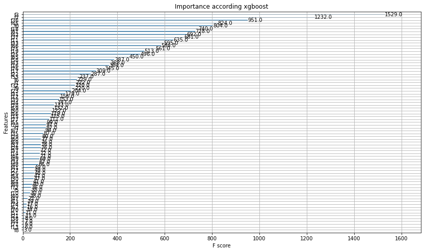

```python
from matplotlib import pyplot as plt

fig = plt.figure(figsize=(14,8))
axes = fig.add_subplot(1,1,1)
xgboost.plot_importance(model_xgb, ax=axes, title='Importance according xgboost')
plt.show()
```

[figure not shown]

```python
fig = plt.figure(figsize=(14,8))
axes = fig.add_subplot(1,1,1)
lightgbm.plot_importance(model_lgbm, ax=axes, title='Importance according lightgbm')
plt.show()
```

In the case of catboost, it doesn't have its own method for plotting importances but they can be easily retrieved from the trained model, so it is possible to plot them with matplotlib.

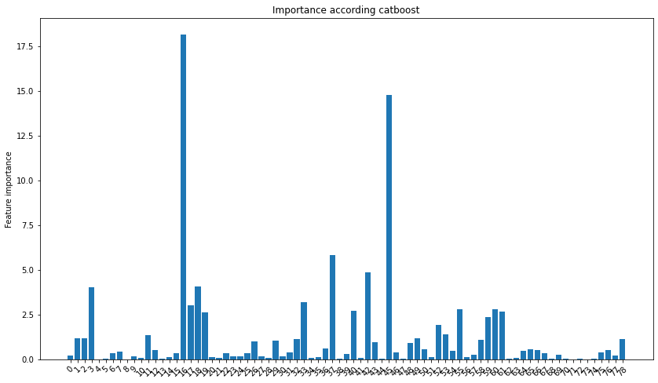

```python
from matplotlib import pyplot as plt

plt.figure(figsize=(14,8))
plt.bar(model_cb.feature_names_, model_cb.feature_importances_)
plt.xticks(rotation=45)
plt.ylabel('Feature importance')
plt.title('Importance according catboost')
plt.show()
```

These plots allow us to have an idea of how important are the different variables for each model just by watching a graph. One of the main conclusions of the these three graphs is that we could build a pretty decent model just by using a reduced number of key variables. In this way our model would win on interpretability but it would also lose in performance.

## Save Notebook in HTML format

```python
!jupyter nbconvert  IonBueno_DanielMartin-A1.ipynb --to html
```

[output not shown]

[output not shown]

[output cut: 116 more lines]

[output not shown]